# Análisis de Machine Learning en el Mercado Inmobiliario de Manhattan

CGCZ

25 de junio de 2025

## 1. Introducción y Preparación de Datos

Este reporte analiza el dataset de ventas de propiedades en Manhattan para cumplir dos objetivos de machine learning: 1. **Regresión:** Predecir el precio de venta de una propiedad. 2. **Clasificación:** Predecir el barrio al que pertenece una propiedad.

### Justificación de la Metodología

Utilizamos un modelo de **regresión lineal** porque nuestra variable objetivo (precio) es numérica y continua. La selección de predictores y transformaciones se justifica de la siguiente manera:

- **Transformación Logarítmica (`log_price`):** El precio de las viviendas y los metros cuadrados suelen tener distribuciones muy asimétricas (sesgadas a la derecha). Aplicar el logaritmo (`log()`) nos ayuda a **estabilizar la varianza** (cumplir el supuesto de homocedasticidad) y a **linealizar la relación** entre las variables, haciendo el modelo lineal más apropiado y sus resultados más fiables.
- **Predictores Seleccionados:**
  - `GROSS_SQFT`: Un proxy directo del **tamaño** de la propiedad. Se espera una fuerte relación positiva con el precio.
  - `age`: Mide la **antigüedad**. Su efecto puede ser complejo: puede indicar deterioro (negativo) o valor histórico (positivo).
  - `RES_UNITS` y `TOTAL_UNITS`: Indican el **tipo y densidad** de la propiedad (ej. casa unifamiliar vs. edificio de apartamentos).
  - `NEIGHBORHOOD`: La **ubicación**, a menudo el predictor más importante del valor inmobiliario.

```r
# Carga y limpieza de datos
file_path <- "../../chapter-02/data/rollingsales_manhattan.xls"
raw2 <- read_excel(file_path, sheet = 1, skip = 4)

df_house <- raw2 %>%
  rename(
    SALE_PRICE = `SALE\nPRICE`, LAND_SQFT = `LAND SQUARE FEET`,
    GROSS_SQFT = `GROSS SQUARE FEET`, YEAR_BUILT = `YEAR BUILT`,
    RES_UNITS = `RESIDENTIAL UNITS`, COMM_UNITS = `COMMERCIAL UNITS`,
    TOTAL_UNITS = `TOTAL UNITS`
  ) %>%
  filter(!is.na(SALE_PRICE), !is.na(NEIGHBORHOOD), GROSS_SQFT > 0, LAND_SQFT > 0, SALE_PRICE > 1000) %>%
  mutate(NEIGHBORHOOD = as.factor(NEIGHBORHOOD), age = 2024 - YEAR_BUILT, log_price = log(SALE_PRICE)) %>%
  select(log_price, SALE_PRICE, NEIGHBORHOOD, GROSS_SQFT, LAND_SQFT, age, RES_UNITS, COMM_UNITS, TOTAL_UNITS)
```

## 2. Modelado de Precios Mediante Regresión

### Modelo 1: Basado en Características Físicas

Nuestro primer modelo intenta predecir el `log_price` usando solo las características físicas de la propiedad.

```r
model_1 <- lm(log_price ~ GROSS_SQFT + age + RES_UNITS + TOTAL_UNITS, data = df_house)
metrics_model_1 <- glance(model_1)
```

### Modelo 2: Incorporando la Ubicación

El R² ajustado del primer modelo (0.706) es robusto, pero sospechamos que la ubicación puede mejorarlo significativamente.

```r
# Ajuste del modelo 2
model_2 <- lm(log_price ~ GROSS_SQFT + age + RES_UNITS + TOTAL_UNITS + NEIGHBORHOOD, data = df_house)
metrics_model_2 <- glance(model_2)

# Crear y mostrar la tabla comparativa
comparison_df <- bind_rows(
  "Modelo 1 (Físico)" = metrics_model_1,
  "Modelo 2 (Físico + Ubicación)" = metrics_model_2,
  .id = "Modelo"
) %>%
  select(Modelo, r.squared, adj.r.squared, sigma)

kable(
  comparison_df,
  caption = "Comparación de Rendimiento de Modelos de Regresión",
  digits = 3
)
```

Comparación de Rendimiento de Modelos de Regresión

| Modelo | r.squared | adj.r.squared | sigma |
| --- | --- | --- | --- |
| Modelo 1 (Físico) | 0.706 | 0.706 | 1.296 |
| Modelo 2 (Físico + Ubicación) | 0.815 | 0.812 | 1.036 |

La tabla anterior demuestra un **aumento significativo del R² ajustado**, confirmando que la ubicación es un factor predictivo crucial.

### Visualización y Ajuste del Modelo Final

#### Impacto de los Predictores

Para entender qué barrios tienen el mayor impacto, graficamos sus coeficientes del `modelo_2`.

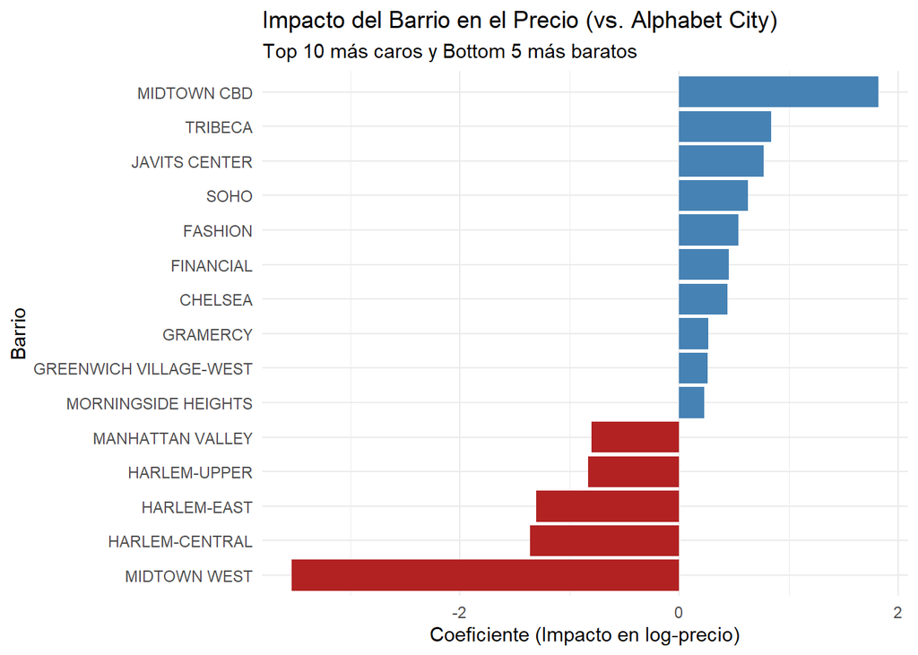

```r
tidy_model_2 <- tidy(model_2)

neighborhood_coefs <- tidy_model_2 %>%
  filter(grepl("NEIGHBORHOOD", term)) %>%
  mutate(term = gsub("NEIGHBORHOOD", "", term)) %>%
  arrange(desc(estimate)) %>%
  slice(c(1:10, (n()-4):n()))

ggplot(neighborhood_coefs, aes(x = estimate, y = reorder(term, estimate), fill = estimate > 0)) +
  geom_col(show.legend = FALSE) +
  scale_fill_manual(values = c("firebrick", "steelblue")) +
  labs(title = "Impacto del Barrio en el Precio (vs. Alphabet City)",
       subtitle = "Top 10 más caros y Bottom 5 más baratos",
       x = "Coeficiente (Impacto en log-precio)", y = "Barrio") +
  theme_minimal()
```

#### Calidad del Ajuste: Valores Reales vs. Predichos

Un buen modelo debe generar predicciones que se alineen con los valores reales. Un gráfico de dispersión en escala logarítmica nos permite verificar esto visualmente.

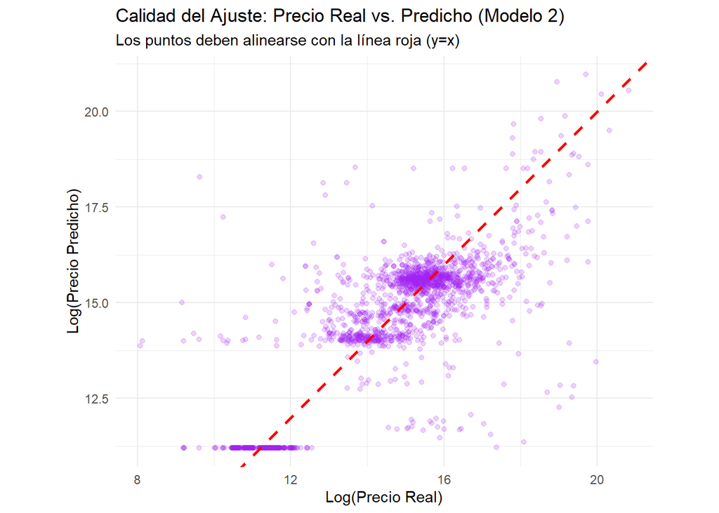

```r
# Añadir predicciones al dataframe
df_house <- df_house %>%
  mutate(predicted_log_price = predict(model_2, .))

# Graficar
ggplot(df_house, aes(x = log_price, y = predicted_log_price)) +
  geom_point(alpha = 0.2, color = "purple") +
  geom_abline(slope = 1, intercept = 0, color = "red", linetype = "dashed", size = 1) +
  labs(title = "Calidad del Ajuste: Precio Real vs. Predicho (Modelo 2)",
       subtitle = "Los puntos deben alinearse con la línea roja (y=x)",
       x = "Log(Precio Real)",
       y = "Log(Precio Predicho)") +
  coord_fixed() + # Asegura una escala 1:1
  theme_minimal()
```

## 3. Clasificación de Barrios con k-NN

Ahora, intentamos predecir el `NEIGHBORHOOD` usando un clasificador k-NN.

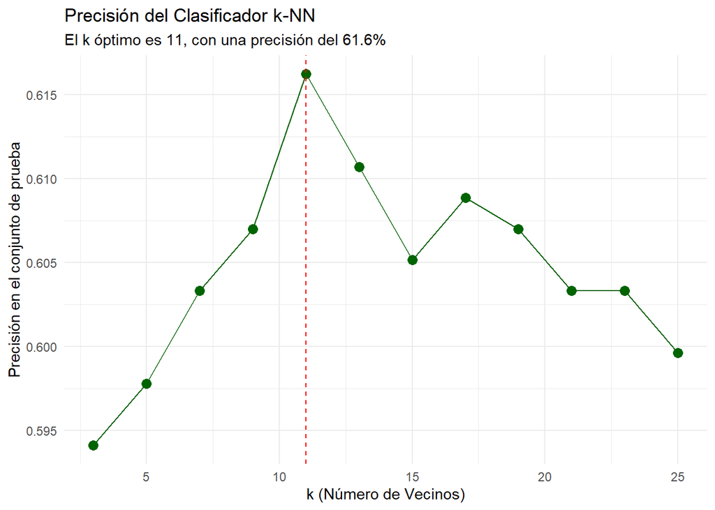

```r
# Preparación de datos y búsqueda del mejor k
set.seed(42)
idx <- sample(nrow(df_house), 0.8 * nrow(df_house))
train <- df_house[idx, ]; test <- df_house[-idx, ]
preds <- c("GROSS_SQFT", "LAND_SQFT", "age", "RES_UNITS", "TOTAL_UNITS")
pp <- preProcess(train[preds], method = c("center", "scale"))
train_sc <- predict(pp, train[preds]); test_sc <- predict(pp, test[preds])
y_tr <- train$NEIGHBORHOOD; y_te <- test$NEIGHBORHOOD
ks <- seq(3, 25, by = 2)
acc <- sapply(ks, function(k) {
  pred_char <- as.character(FNN::knn(train_sc, test_sc, y_tr, k = k))
  mean(pred_char == as.character(y_te))
})
best_k <- ks[which.max(acc)]; best_acc <- max(acc)

# Gráfico de resultados
tibble(k = ks, accuracy = acc) %>%
  ggplot(aes(k, accuracy)) +
  geom_line(color="darkgreen") + geom_point(color="darkgreen", size=3) +
  geom_vline(xintercept = best_k, linetype = "dashed", color = "red") +
  labs(title = "Precisión del Clasificador k-NN",
       subtitle = sprintf("El k óptimo es %d, con una precisión del %.1f%%", best_k, best_acc * 100),
       x = "k (Número de Vecinos)", y = "Precisión en el conjunto de prueba") +
  theme_minimal()
```

## 4. Conclusiones y Acciones Potenciales

### Acciones Recomendadas

- **Inversores:** Usar el modelo de regresión para encontrar propiedades infravaloradas.
- **Portales Inmobiliarios:** Implementar el clasificador k-NN para validar la información de los listados.
- **Gobierno de la Ciudad:** Utilizar los coeficientes del modelo por barrio para informar políticas de vivienda y desarrollo urbano.

## 5. Diagnósticos y Reproducibilidad

### Diagnósticos del Modelo de Regresión

Para asegurar la validez de nuestro modelo final (`modelo_2`), verificamos sus supuestos. El gráfico de Residuos vs. Valores Ajustados es clave para detectar la no-linealidad y la heterocedasticidad. Idealmente, deberíamos ver una nube de puntos sin patrones.

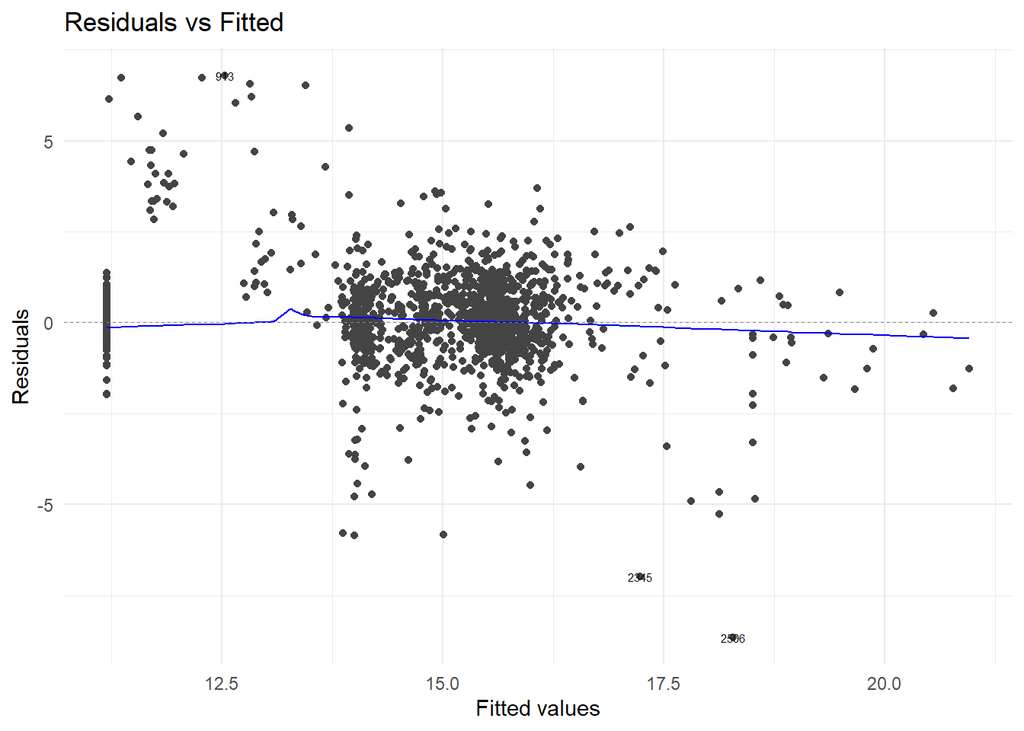

```r
autoplot(model_2, which = 1, ncol = 1, label.size = 2) + theme_minimal()
```